# Lab 8

November 21st 2017

## Bayesian Estimation Supersedes T-test

## Rationale

- Real-life data rarely concord with assumptions of common statistical approaches
- Group variances usually differ (whereas with t-test we assume they are equal)
- Tails of the sampled distribution are usually heavy and include outliers (whereas we assume the data follow Normal distribution)
- Finding proper transformation is often difficult, and removing outliers is usually controversial

## Rationale

- Instead of 'correcting' our data we can try to model them as they are
- JAGS gives us enough flexibility to deal with most of the real-life distributional issues
- Make sure you to read chapter 16 from DBDA
- If you would like to include citation to the method we will cover today go to: http://psycnet.apa.org/record/2012-18082-001

## t distribution

Using t-distribution (instead of Normal) is a way to obtain robust (to outliers) estimates of group variances

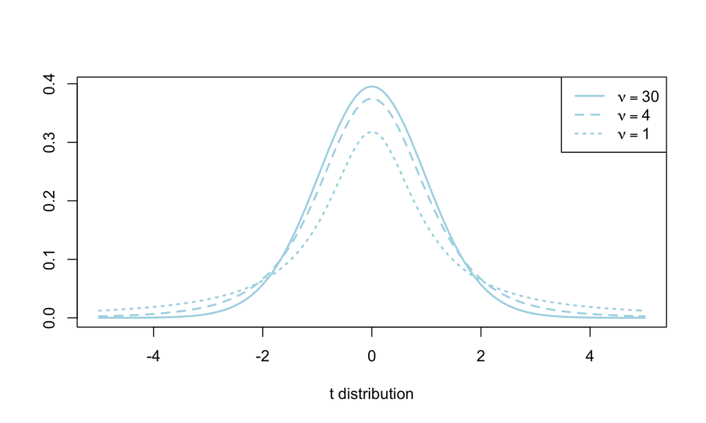

## Prior on \(\nu\) parameter

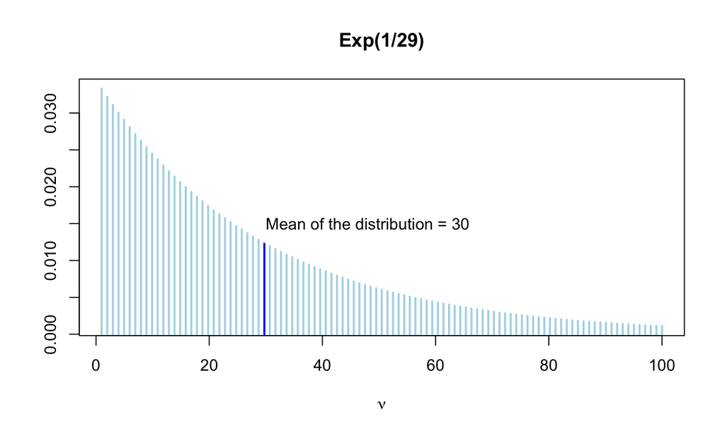

## ROPE

- A region of practical equivalence (ROPE) indicates a small range of parameter values that are considered to be practically equivalent to the null value for purposes of the particular application.
- E.g. if we are assessing the efficacy of a drug versus a placebo, we might only consider using the drug if it improves the probability of cure by at least 5 percentage points. Thus, the ROPE on the diference of cure probabilities could have limits of ±0.05.